# **MScFE 642 DEEP LEARNING FOR FINANCE**

**Group Work Project # 3**

# **Step 1**

The overall task in this step is to build three Deep Learning models to predict the returns of the security of our choice.

We start with importing the relevant libraries and next, we download the data for the security we have a good notion of, namely Apple (AAPL) stock prices.

```python
!pip install pyts -q
```

```python
import yfinance as yf
import pandas as pd
import numpy as np
import tensorflow as tf
import matplotlib.pyplot as plt

from sklearn.model_selection import train_test_split
from sklearn.linear_model import LinearRegression
from sklearn.metrics import mean_squared_error
from sklearn.preprocessing import MinMaxScaler
from keras.models import Sequential
from keras.layers import Dense, LSTM, Conv1D, Flatten, MaxPooling1D
from tensorflow.keras.layers import Conv2D, MaxPooling2D, Flatten, Dense
from pyts.image import GramianAngularField
from tensorflow.keras import layers

import warnings
warnings.filterwarnings('ignore')

np.random.seed(42)
tf.random.set_seed(42)

import os
os.environ['PYTHONHASHSEED'] = '0'
```

## **Step 1a**

To fulfill the time series length requirement of no more than 2,000 observations, we take the data from 02/01/2016 to 01/01/2024, which results in a set of 1,993 observations.

```python
# data
data = yf.download('AAPL', start='2016-02-01', end='2024-01-01')

time_series = data['Close'].pct_change().dropna().values
# Display basic information about the dataset
print(data.info())
data.head()
```

```
[*********************100%%**********************]  1 of 1 completed
```

```
<class 'pandas.core.frame.DataFrame'>
DatetimeIndex: 1993 entries, 2016-02-01 to 2023-12-29
Data columns (total 6 columns):
 #   Column     Non-Null Count  Dtype
---  ------     --------------  -----
 0   Open       1993 non-null   float64
 1   High       1993 non-null   float64
 2   Low        1993 non-null   float64
 3   Close      1993 non-null   float64
 4   Adj Close  1993 non-null   float64
 5   Volume     1993 non-null   int64
dtypes: float64(5), int64(1)
memory usage: 109.0 KB
None
```

| Date | Open | High | Low | Close | Adj Close | Volume |
| --- | --- | --- | --- | --- | --- | --- |
| 2016-02-01 | 24.117500 | 24.177500 | 23.850000 | 24.107500 | 21.919331 | 163774000 |
| 2016-02-02 | 23.855000 | 24.010000 | 23.570000 | 23.620001 | 21.476074 | 149428800 |
| 2016-02-03 | 23.750000 | 24.209999 | 23.520000 | 24.087500 | 21.901146 | 183857200 |
| 2016-02-04 | 23.965000 | 24.332500 | 23.797501 | 24.150000 | 22.077122 | 185886800 |
| 2016-02-05 | 24.129999 | 24.230000 | 23.422501 | 23.504999 | 21.487480 | 185672400 |

Below we visualize the (well-known) behavior of this security.

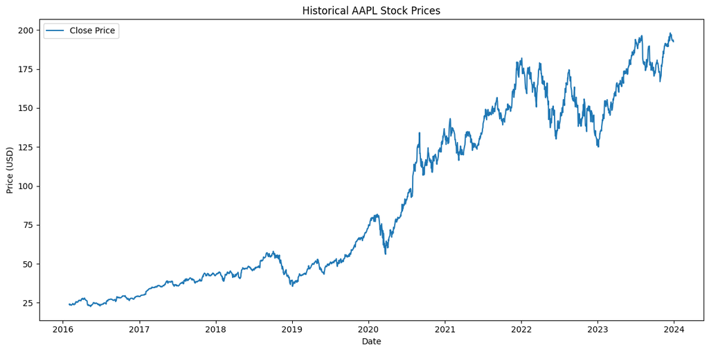

```python
# Visualize
plt.figure(figsize=(12, 6))
plt.plot(data.index, data['Close'], label='Close Price')
plt.title('Historical AAPL Stock Prices')
plt.xlabel('Date')
plt.ylabel('Price (USD)')
plt.legend()
plt.tight_layout()
plt.savefig('aapl_prices.png')
plt.show();
```

In the above graph we can see that AAPL has been experiencing increased volatility since the COVID-19 pandemic outburst in March 2020. In hindsight, that period of significant drops resulted in hitting the new historical highs a few times, and each of them is greater than the historical high from before the pandemic.

Finally, we take a brief look at the summary statistics to confront the visual analysis with the numerical outcome.

```python
round(data['Close'].describe(), 2)
```

```
count    1993.00
mean       91.42
std        55.76
min        22.58
25%        41.94
50%        67.86
75%       146.09
max       198.11
Name: Close, dtype: float64
```

The standard deviation of 55.76 USD in the entire analyzed period is relatively high, as compared with the mean of 91.42 USD. However, the minimum, the 25th and the 50th percentile are almost perfectly equidistant from each other, indicating certain stability in the stock price growth over the analyzed period. An exception here is the 75th percentile and the maximum, indicating that there has been a rapid growth in the security price.

## **Step 1b**

Now we create the target column `Returns` and the respective lagged values from 1 to 6 days. We apply the same reasoning as in the previous projects, where we used 6 lags to capture the returns' behavior from the past business week. We deem including higher-order lags redudant and potentially even introducing noise to the model instead of adding information.

Additionally, as in the previous projects, we consider the task to be an autoregression problem.

```python
# Calculate the returns
data['Returns'] = data.loc[:, 'Close'].pct_change()
for i in range(6):
  data[f'Returns_Lag_{i+1}'] = data.loc[:, 'Returns'].shift(i+1)

# Remove missing values
data = data.dropna()
data.head()
```

| Date | Open | High | Low | Close | Adj Close | Volume | Returns | Returns_Lag_1 | Returns_Lag_2 | Returns_Lag_3 | Returns_Lag_4 | Returns_Lag_5 | Returns_Lag_6 |
| --- | --- | --- | --- | --- | --- | --- | --- | --- | --- | --- | --- | --- | --- |
| 2016-02-10 | 23.980000 | 24.0875 | 23.525000 | 23.567499 | 21.544619 | 169374400 | -0.007580 | -0.000211 | 0.010530 | -0.026708 | 0.002595 | 0.019792 | -0.020222 |
| 2016-02-11 | 23.447500 | 23.6800 | 23.147499 | 23.424999 | 21.414352 | 200298800 | -0.006046 | -0.007580 | -0.000211 | 0.010530 | -0.026708 | 0.002595 | 0.019792 |
| 2016-02-12 | 23.547501 | 23.6250 | 23.252501 | 23.497499 | 21.480623 | 161405600 | 0.003095 | -0.006046 | -0.007580 | -0.000211 | 0.010530 | -0.026708 | 0.002595 |
| 2016-02-16 | 23.754999 | 24.2125 | 23.652500 | 24.160000 | 22.086264 | 196231600 | 0.028195 | 0.003095 | -0.006046 | -0.007580 | -0.000211 | 0.010530 | -0.026708 |
| 2016-02-17 | 24.167500 | 24.5525 | 24.037500 | 24.530001 | 22.424509 | 179452800 | 0.015315 | 0.028195 | 0.003095 | -0.006046 | -0.007580 | -0.000211 | 0.010530 |

Naturally, including the 6 lagged values of returns resulted in shortening the initial dataset by 7 observations (1 for creating the column `Returns` and 6 for the respective lags).

To get an idea of the potential modeling issues that may occur due to the data characteristics, we visualize the data.

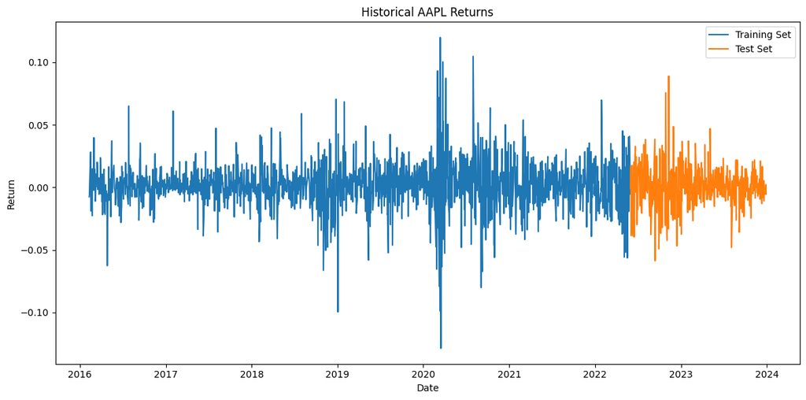

```python
# Split the data into training and test sets
X = data[data.columns[-6:]]
y = data['Returns']
X_train, X_test, y_train, y_test = train_test_split(X, y, test_size=0.2, shuffle=False)

# Visualize
plt.figure(figsize=(12, 6))
plt.plot(y_train, label='Training Set')
plt.plot(y_test, label='Test Set')
plt.title('Historical AAPL Returns')
plt.xlabel('Date')
plt.ylabel('Return')
plt.legend()
plt.tight_layout()
plt.savefig('aapl_returns.png')
plt.show();
```

As per the assigned task, our data in the first two steps is supposed to have an issue of **data leakage**. The issue is that during training we (deliberately, in this case) include the data that should not have been "seen" by the model and used to learn data patterns, e.g., by incorporating future data or including the target variable in features, directly or indirectly (via feature engineering). This, in turn, may lead to overly optimistic model performance on the training set and consequently a significant performance drop on the test set.

We decided to create data leakage by shifting the first lagged return by 1 observation so that we actually train the model to predict today's return using today's return and its lagged values from 2 to 6 days.

```python
# Including leaky data
X_train['Returns_Lag_1'] = y_train
X_train.tail()
```

| Date | Returns_Lag_1 | Returns_Lag_2 | Returns_Lag_3 | Returns_Lag_4 | Returns_Lag_5 | Returns_Lag_6 |
| --- | --- | --- | --- | --- | --- | --- |
| 2022-05-24 | -0.019216 | 0.001747 | -0.024641 | -0.056419 | 0.025423 | -0.010672 |
| 2022-05-25 | 0.001140 | 0.040119 | 0.001747 | -0.024641 | -0.056419 | 0.025423 |
| 2022-05-26 | 0.023200 | -0.019216 | 0.040119 | 0.001747 | -0.024641 | -0.056419 |
| 2022-05-27 | 0.040757 | 0.001140 | -0.019216 | 0.040119 | 0.001747 | -0.024641 |
| 2022-05-31 | -0.005346 | 0.023200 | 0.001140 | -0.019216 | 0.040119 | 0.001747 |

That way we mimic a situation when the analyst accidentally includes future information in the training dataset. We expect an extraordinary model performance on the training set and a significant drop in performance on the test set.

We create a linear regression model (without any tuning or checking for modeling assumptions fulfillment) that will later serve as a baseline for the Deep Learning models.

```
LR Train MSE: 2.4951223545987883e-34
LR Test MSE: 0.0005855545047203337
```

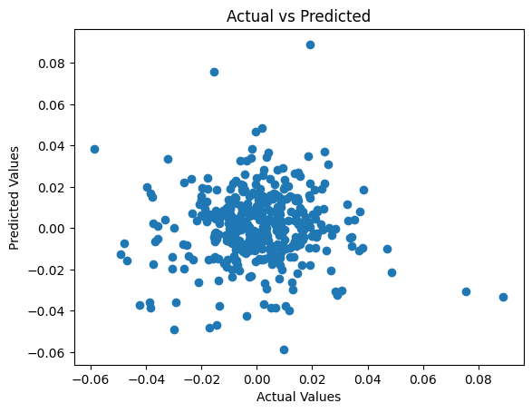

```python
# Build the linear regression model
model = LinearRegression()
model.fit(X_train, y_train)

# Make predictions on the test set
y_pred = model.predict(X_test)
#print(y_pred)
# Evaluate the model
mse_train = mean_squared_error(model.predict(X_train), y_train)
print('LR Train MSE:', mse_train)
mse_test = mean_squared_error(y_test, y_pred)
print('LR Test MSE:', mse_test)

# Plot the actual versus predicted values
plt.scatter(y_test, y_pred)
plt.xlabel('Actual Values')
plt.ylabel('Predicted Values')
plt.title('Actual vs Predicted')
plt.savefig('baseline_linear_regression.png')
plt.show();
```

## **Step 1c**

In this subtask we create the Deep Learning models:

- MLP
- LSTM
- CNN with GAF representation.

It is beneficial for all models to be trained on scaled data, therefore we apply min-max scaling.

We use the following model specifications:

```python
# Normalize the data separately for each model
scaler_mlp = MinMaxScaler()

# MLP Model
X_train_mlp = scaler_mlp.fit_transform(np.array(X_train))
y_train_mlp = scaler_mlp.fit_transform(np.array(y_train).reshape(-1, 1))
X_test_mlp = scaler_mlp.transform(np.array(X_test).reshape(-1, 1))
y_test_mlp = scaler_mlp.transform(np.array(y_test).reshape(-1, 1))

scaler_lstm = MinMaxScaler()

# LSTM Model
X_train_lstm = scaler_lstm.fit_transform(np.array(X_train))
y_train_lstm = scaler_lstm.fit_transform(np.array(y_train).reshape(-1, 1))
X_test_lstm = scaler_lstm.transform(np.array(X_test).reshape(-1, 1))
y_test_lstm = scaler_lstm.transform(np.array(y_test).reshape(-1, 1))

# CNN based on GAF Model
window_size = 6  # Length of the sliding window

# Normalize the data
scaler_cnn = MinMaxScaler()
X_train_scaled = scaler_cnn.fit_transform(np.array(X_train))
X_test_scaled = scaler_cnn.transform(np.array(X_test))
y_train_cnn = scaler_cnn.fit_transform(np.array(y_train).reshape(-1, 1))
y_test_cnn = scaler_cnn.transform(np.array(y_test).reshape(-1, 1))

# Generate GAF images
gaf = GramianAngularField(image_size=window_size, method='difference')
X_train_gaf = gaf.fit_transform(X_train_scaled)
X_test_gaf = gaf.transform(X_test_scaled)

# Reshape the data for CNN input [samples, width, height, channels]
X_train_cnn = X_train_gaf.reshape(-1, window_size, window_size, 1)
X_test_cnn = X_test_gaf.reshape(-1, window_size, window_size, 1)

# Split the data into training and testing sets for CNN

# Train and evaluate the models
# MLP Model
mlp_model = Sequential()
mlp_model.add(Dense(64, activation='relu', input_dim=6))
mlp_model.add(Dense(1))
mlp_model.compile(optimizer='adam', loss='mse')
mlp_model.fit(X_train_mlp, y_train_mlp, epochs=20, batch_size=32, verbose=False)

# LSTM Model
lstm_model = Sequential()
lstm_model.add(LSTM(64, activation='relu', input_shape=(1, 6)))
lstm_model.add(Dense(1))
lstm_model.compile(optimizer='adam', loss='mse')
lstm_model.fit(X_train_lstm.reshape(-1, 1, 6), y_train_lstm, epochs=20, batch_size=32, verbose=False)

# CNN Model
cnn_model = Sequential()
cnn_model.add(Conv2D(32, kernel_size=(3, 3), activation='relu', input_shape=(window_size, window_size, 1)))
cnn_model.add(MaxPooling2D(pool_size=(2, 2)))
cnn_model.add(Flatten())
cnn_model.add(Dense(64, activation='relu'))
cnn_model.add(Dense(1, activation='linear'))
cnn_model.compile(optimizer='adam', loss='mean_squared_error')
cnn_model.fit(X_train_cnn, y_train_cnn, epochs=20, batch_size=32, verbose=False)

# Evaluation
mlp_train_loss = mlp_model.evaluate(X_train_mlp.reshape(len(y_train), 6), y_train_mlp)
lstm_train_loss = lstm_model.evaluate(X_train_lstm.reshape(-1, 1, 6), y_train_lstm)
cnn_train_loss = cnn_model.evaluate(X_train_cnn, y_train_cnn)

print('MLP Train Loss:', mlp_train_loss)
print('LSTM Train Loss:', lstm_train_loss)
print('CNN Train Loss:', cnn_train_loss)

# Evaluation
mlp_test_loss = mlp_model.evaluate(X_test_mlp.reshape(len(y_test), 6), y_test)
lstm_test_loss = lstm_model.evaluate(X_test_lstm.reshape(-1, 1, 6), y_test)
cnn_test_loss = cnn_model.evaluate(X_test_cnn, y_test_cnn)

print('MLP Test Loss:', mlp_test_loss)
print('LSTM Test Loss:', lstm_test_loss)
print('CNN Test Loss:', cnn_test_loss)
```

```
MLP Train Loss: 2.5561792426742613e-05
LSTM Train Loss: 1.7652557289693505e-05
CNN Train Loss: 0.0025459923781454563
MLP Test Loss: 0.2747378945350647
LSTM Test Loss: 0.2755730152130127
CNN Test Loss: 0.009123961441218853
```

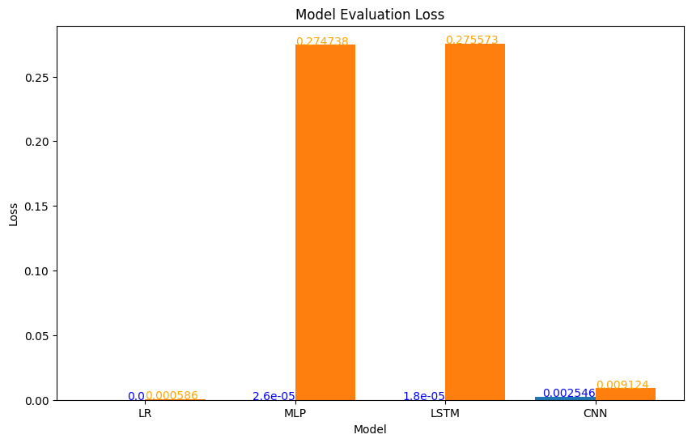

```python
# Define the model names and losses
model_names = ['LR', 'MLP', 'LSTM', 'CNN']
losses_train = [mse_train, mlp_train_loss, lstm_train_loss, cnn_train_loss]
losses_test = [mse_test, mlp_test_loss, lstm_test_loss, cnn_test_loss]

# Plot the losses
plt.figure(figsize=(10, 6))
plt.bar(model_names, losses_train, width=-0.4, label='Train', align='edge')
plt.bar(model_names, losses_test, width=0.4, label='Test', align='edge')
plt.xlabel('Model')
plt.ylabel('Loss')
for i in range(len(model_names)):
  plt.text(i, losses_train[i], round(losses_train[i],6), ha='right', color='blue')
  plt.text(i, losses_test[i], round(losses_test[i],6), ha='left', color='orange')
plt.title('Model Evaluation Loss')
plt.savefig('step_1c_modeling_losses.png')
plt.show();
```

```python
for i in range(len(losses_test)):
  print(model_names[i], '% difference between test and train loss:', round(losses_test[i]/losses_train[i], 2))
```

```
LR % difference between test and train loss: 2.346796755842821e+30
MLP % difference between test and train loss: 10747.99
LSTM % difference between test and train loss: 15610.94
CNN % difference between test and train loss: 3.58
```

We can clearly see the effect of data leakage: train losses of all models are nearly 0, whereas test losses are much higher:

Without any hyperparameter tuning, the baseline linear regression model is overall the best-performer, followed by CNN with GAF representation. Conversely, MLP and LSTM models have much greater test loss. In the wake of the findings from the previous project it is quite a surprising result since CNN was not expected to work well for financial data.

It is possible that MLP and LSTM would perform better after hyperparameter tuning, however to maintain computational feasibility we skip this step.

## **Step 1d**

The strategy is as follows: if the predicted next-day return is above the current-day return, buy; sell short if the predicted next-day return is below the current-day return.

### MLP

First, we test the strategy on the MLP model.

```python
# Perform backtest
initial_capital = 10000  # Initial capital in USD
current_capital = initial_capital
shares = 0
total_trades = 0
winning_trades = 0
# Retrieve the prices in the testing period
train_size = int(len(X_train_mlp))
test_prices = data['Close'][-len(y_test):]
X_test_mlp_reshaped = X_test_mlp.reshape(len(y_test), 6)

# Predict the next day's return using the MLP model
predicted_price = mlp_model.predict(X_test_mlp_reshaped, verbose=False)
predicted_price = scaler_mlp.inverse_transform(predicted_price)

for i in range(len(y_test)):
    # Buy signal: If the predicted return increase is above a threshold, buy shares
    if predicted_price[i] > y_test[i]:
        shares_to_buy = int(current_capital / test_prices[i])
        shares += shares_to_buy
        current_capital -= shares_to_buy * test_prices[i]
        total_trades += 1
        winning_trades += 1

    # Sell signal: If the predicted return decrease is below a threshold, sell shares
    elif predicted_price[i] < y_test[i]:
        current_capital += shares * test_prices[i]
        shares = 0
        total_trades += 1

# Calculate the final portfolio value
final_portfolio_value = current_capital + shares * test_prices[-1]
percent_gain = ((final_portfolio_value - initial_capital) / initial_capital) * 100

# Print the results
results_mlp_df = pd.DataFrame([initial_capital, final_portfolio_value, percent_gain, total_trades, winning_trades],
                              index=['Initial Capital', 'Final Portfolio Value', 'Percentage Gain', 'Total Trades', 'Winning Trades'],
                              columns=['Value'])
results_mlp_df.round(2)
```

|  | Value |
| --- | --- |
| Initial Capital | 10000.00 |
| Final Portfolio Value | 9411.19 |
| Percentage Gain | -5.89 |
| Total Trades | 398.00 |
| Winning Trades | 199.00 |

We observe a loss on the test set. This is likely caused by the data leakage issue. Hence, our model predictions on the test set are noticeably inaccurate, affecting the strategy negatively.

### LSTM

Next, we perform backtesting of the same strategy for the LSTM model.

```python
X_test_lstm_reshaped = X_test_lstm.reshape(len(y_test_lstm), 1, 6)

# Perform backtest
initial_capital = 10000  # Initial capital in USD
current_capital = initial_capital
shares = 0
total_trades = 0
winning_trades = 0
time_steps = 6

# Predict the next day's price using the LSTM model
predicted_price = lstm_model.predict(X_test_lstm_reshaped, verbose=False)
predicted_price = scaler_lstm.inverse_transform(predicted_price)

for i in range(len(X_test_lstm_reshaped)):
    # Buy signal: If the predicted price increase is above a threshold, buy shares
    if predicted_price[i] > y_test[i]:
        shares_to_buy = int(current_capital / test_prices[i])
        shares += shares_to_buy
        current_capital -= shares_to_buy * test_prices[i]
        total_trades += 1
        winning_trades += 1

    # Sell signal: If the predicted price decrease is below a threshold, sell shares
    elif predicted_price[i] < y_test[i]:
        current_capital += shares * test_prices[i]
        shares = 0
        total_trades += 1

# Calculate the final portfolio value
final_portfolio_value = current_capital + shares * test_prices[-1]
percent_gain = ((final_portfolio_value - initial_capital) / initial_capital) * 100

# Print the results
results_lstm_df = pd.DataFrame([initial_capital, final_portfolio_value, percent_gain, total_trades, winning_trades],
                              index=['Initial Capital', 'Final Portfolio Value', 'Percentage Gain', 'Total Trades', 'Winning Trades'],
                              columns=['Value'])
results_lstm_df.round(2)
```

|  | Value |
| --- | --- |
| Initial Capital | 10000.00 |
| Final Portfolio Value | 9557.52 |
| Percentage Gain | -4.42 |
| Total Trades | 398.00 |
| Winning Trades | 199.00 |

Similarly to the MLP model, we observe a loss on the test set. The same reasoning applies.

### CNN with GAF Representation

Lastly, we backtest the strategy on the CNN with GAF Representation.

```python
# Perform backtest
initial_capital = 10000  # Initial capital in USD
current_capital = initial_capital
shares = 0
total_trades = 0
winning_trades = 0
window_size = 6

# Predict the next day's return using the CNN model
predicted_price = cnn_model.predict(X_test_cnn, verbose=False)
predicted_price = scaler_cnn.inverse_transform(predicted_price)

for i in range(len(X_test_cnn)):
    # Buy signal: If the predicted price increase is above a threshold, buy shares
    if predicted_price[i] > y_test[i]:
        shares_to_buy = int(current_capital / test_prices[i])
        shares += shares_to_buy
        current_capital -= shares_to_buy * test_prices[i]
        total_trades += 1
        winning_trades += 1

    # Sell signal: If the predicted price decrease is below a threshold, sell shares
    elif predicted_price[i] < y_test[i]:
        current_capital += shares * test_prices[i]
        shares = 0
        total_trades += 1

# Calculate the final portfolio value
final_portfolio_value = current_capital + shares * test_prices[-1]
percent_gain = ((final_portfolio_value - initial_capital) / initial_capital) * 100

# Print the results
results_cnn_df = pd.DataFrame([initial_capital, final_portfolio_value, percent_gain, total_trades, winning_trades],
                              index=['Initial Capital', 'Final Portfolio Value', 'Percentage Gain', 'Total Trades', 'Winning Trades'],
                              columns=['Value'])
results_cnn_df.round(2)
```

|  | Value |
| --- | --- |
| Initial Capital | 10000.00 |
| Final Portfolio Value | 10404.67 |
| Percentage Gain | 4.05 |
| Total Trades | 398.00 |
| Winning Trades | 231.00 |

As expected, the CNN model has biggest gain. Yet the return is significantly lower than the baseline buy-and-hold strategy return.

# **Step 2**

In this step, we explore the walk-forward method of model training. We are again working with MLP, LSTM and CNN with GAF representation models, however, this time we apply different train-test splits.

## **Step 2a**

First, we are working with a train-test split of 50:50, i.e., each model is trained on 500 observations and then tested on another 500 observations.

We start with defining model-creating functions and apply each of the models - MLP, LSTM and GAF based CNN.

Again, we ensure that there is data leakage to the training set, the same as defined in Step 1.

```python
# Initalize features and target
X = data[data.columns[-6:]]
y = data['Returns']
p = data['Close']

# Split the data into train and test sets
train_size = 500
# Ensure that there is data leakage to the training set (but not to the test dataset)
X['Returns_Lag_1'].iloc[:train_size] = y.iloc[:train_size]

n_input = 6
df = data
n_train = 500
n_test = 500
```

Here we create all help functions to source data in the format required for each of the models

```python
def create_lstm_model(n_input):
  """
  Creates a LSTM model for prediction.

  :param n_input: specifies number of features
  :return: model
  """
  # Train the LSTM model
  lstm_model = Sequential()
  lstm_model.add(LSTM(64, activation='relu', input_shape=(1, n_input)))
  lstm_model.add(Dense(1))
  lstm_model.compile(optimizer='adam', loss='mse')
  return lstm_model

def create_mlp_model(n_input):
  """
  Creates a MLP model for prediction.

  :param n_input: specifies number of features
  :return: model
  """
  model = Sequential()
  model.add(Dense(64, activation='relu', input_dim=n_input))
  model.add(Dense(1))
  model.compile(optimizer='adam', loss='mse')
  return model

def create_cnn_model(n_input=6):
  """
  Creates a CNN model for prediction.

  :param n_input: specifies number of features
  :return: model
  """
  cnn_model = Sequential([
      Conv2D(32, kernel_size=(3, 3), activation='relu', input_shape=(n_input, n_input, 1)),
      MaxPooling2D(pool_size=(2, 2)),
      Flatten(),
      Dense(100, activation='relu'),
      Dense(1)
  ])
  cnn_model.compile(loss='mean_squared_error', optimizer='adam')

  return cnn_model
```

The code to perform a non anchored walk forward has been written in a generic way.

```python
# Helper functions to get data with the correct shapes
def get_lstm_data(X, y, train=True):
  X_train = scaler_lstm.fit_transform(np.array(X))
  y_train = scaler_lstm.fit_transform(np.array(y).reshape(-1, 1))
  X_test = scaler_lstm.transform(np.array(X).reshape(-1, 1))
  y_test = scaler_lstm.transform(np.array(y).reshape(-1, 1))

  if train:
    return X_train, y_train
  else:
    return X_test, y_test

def get_gaf_data(X, y, train=True):
  # CNN based on GAF Model
  window_size = 6  # Length of the sliding window

  # Normalize the data
  X_train_scaled = scaler_cnn.fit_transform(np.array(X_train))
  X_test_scaled = scaler_cnn.transform(np.array(X_test))
  y_train_cnn = scaler_cnn.fit_transform(np.array(y_train).reshape(-1, 1))
  y_test_cnn = scaler_cnn.transform(np.array(y_test).reshape(-1, 1))

  # Generate GAF images
  gaf = GramianAngularField(image_size=window_size, method='difference')
  X_train_gaf = gaf.fit_transform(X_train_scaled)
  X_test_gaf = gaf.transform(X_test_scaled)

  # Reshape the data for CNN input [samples, width, height, channels]
  X_train_cnn = X_train_gaf.reshape(-1, window_size, window_size, 1)
  X_test_cnn = X_test_gaf.reshape(-1, window_size, window_size, 1)
  if train:
    return X_train_cnn, y_train_cnn
  else:
    return X_test_cnn, y_test_cnn

def walk_forward(df, model, ModelType, n_train, n_test):
    """
    Peform Non-anchored Walk Forward on observation data using parameters

    :param df: dataframe of securities data
    :param model: model used for prediction using walk forward
    :param ModelType: type of the model passed for walk forward
    :param n_train: number of observations for train
    :param n_test: number of parameters for test
    :return: dataframe
    """

    time_backtest = np.array([]).astype("datetime64[ns]", copy=False)
    pred_backtest = []
    ret_backtest = []

    #print("Len Y", len(y))

    for i in range(0, len(y)-n_train, n_test):
        X_train, X_test = X[i:(i + n_train)], X[(i + n_train):(i + n_train + n_test)]
        y_train, y_test = y[i:(i + n_train)], y[(i + n_train):(i + n_train + n_test)]

        # Read the index values
        #print("Len:", len(X_train))
        test_time = df.iloc[(i + n_train):(i + n_train + n_test), 0:1].index.values
        Ret_vector = df.iloc[(i + n_train):(i + n_train + n_test), 6:7].values

        print(i,
              #i + (n_train), i + n_train + n_test,
              "ite ",
              i / n_test,
              " --start test:",
              test_time[0].astype('datetime64[D]'),
              " --end test",
              test_time[-1].astype('datetime64[D]'),
              " ----- ",
              X_train.shape,
              y_train.shape,
              X_test.shape,
              y_test.shape,
              test_time.shape,
              Ret_vector.shape,
              )

        # Fit the model
        if ModelType == 'MLP':
            try:
                model.fit(X_train, y_train, epochs=20, batch_size=32, verbose=False)
                y_pred = model.predict(X_test, verbose=False)
                time_backtest = np.append(time_backtest, test_time.flatten())
                pred_backtest = np.append(pred_backtest, y_pred.flatten())
                ret_backtest = np.append(ret_backtest, Ret_vector.flatten())
            except Exception as e:
                print("Error occurred during MLP model training:", e)
                # Reshape the data to have smaller dimensions
                X_train, X_test = X_train.reshape(-1, 1), X_test.reshape(-1, 1)
                print("Reshape sucessful")

        elif ModelType == 'LSTM':
            try:
                test_time = df.iloc[(i + len(X_train)):(i + n_train + n_test), 0:1].index.values
                Ret_vector = df.iloc[(i + n_train):(i + n_train + n_test), 6:7].values
                X_train_lstm, y_train_lstm = get_lstm_data(X_train, y_train)
                X_train_lstm = X_train_lstm.reshape(n_train, 1, n_input)
                model.fit(X_train_lstm, y_train_lstm, epochs=20, batch_size=32, verbose=False)
                # Predictions on the test data
                X_test_lstm, y_test_lstm = get_lstm_data(X_test, y_test, False)
                y_pred = model.predict(X_test_lstm.reshape(n_test, 1, n_input), verbose=False)

                time_backtest = np.append(time_backtest, test_time.flatten())
                pred_backtest = np.append(pred_backtest, y_pred.flatten())
                ret_backtest = np.append(ret_backtest, Ret_vector.flatten())

                print(time_backtest.shape, pred_backtest.shape, ret_backtest.shape)
            except Exception as e:
                print("Error occurred during LSTM model training:", e)
                # Reshape the data to have smaller dimensions
                X_train_lstm, X_test_lstm = X_train_lstm.reshape(-1, 1, n_input), X_test_lstm.reshape(-1, 1, n_input)
                print("Reshape sucessful")

        elif ModelType == 'CNN':
            try:
                # Normalize the target variable
                test_time = df.iloc[(i+n_train):(i+n_train+n_test), 0:1].index.values
                Ret_vector = df.iloc[(i+n_train):(i+n_train+n_test), 6:7].values

                scaler = MinMaxScaler()
                target = scaler.fit_transform(y.values.reshape(-1, 1)).flatten()
                X_train_GAF, y_train_GAF = get_gaf_data(X, y)
                # CNN model
                model.fit(X_train_GAF, y_train_GAF, epochs=20, batch_size=32, verbose=False)

                # Predict the target variable using the CNN model
                X_test_GAF, y_test_GAF = get_gaf_data(X, y, False)
                y_test_pred = model.predict(X_test_GAF)

                pred_backtest = np.append(pred_backtest, y_test_pred.flatten())
                time_backtest = np.append(time_backtest, test_time.flatten())
                ret_backtest = np.append(ret_backtest, Ret_vector.flatten())
                print(len(ret_backtest))
                print("->", time_backtest.shape, pred_backtest.shape, ret_backtest.shape)
            except Exception as e:
                print("Error occurred during CNN model training:", e)
                # Reshape the data to have smaller dimensions
                X_train_GAF, X_test_GAF = X_train_GAF.reshape(-1, window_size, window_size, 1), X_test_GAF.reshape(-1, window_size, window_size, 1)
                print("Reshape sucessful")

    # Ensure consistency in the lengths of arrays
    min_length = min(len(time_backtest), len(pred_backtest), len(ret_backtest))
    time_backtest = time_backtest[:min_length]
    pred_backtest = pred_backtest[:min_length]
    ret_backtest = ret_backtest[:min_length]

    df_predictions = pd.DataFrame({
        'Date': time_backtest,
        'Pred': pred_backtest,
        'Ret': ret_backtest
    })

    # Specify the unit for the 'Date' column (assuming it's datetime)
    df_predictions["Date"] = pd.to_datetime(df_predictions["Date"])

    return df_predictions
```

```python
mlp_model = create_mlp_model(n_input)
df_res1 = walk_forward(df, mlp_model, 'MLP', n_train, n_test)
df_res1.head()
```

```
0 ite  0.0  --start test: 2018-02-05  --end test 2020-01-30  -----  (500, 6) (500,) (500, 6) (500,) (500,) (500, 1)
500 ite  1.0  --start test: 2020-01-31  --end test 2022-01-24  -----  (500, 6) (500,) (500, 6) (500,) (500,) (500, 1)
1000 ite  2.0  --start test: 2022-01-25  --end test 2023-12-29  -----  (500, 6) (500,) (486, 6) (486,) (486,) (486, 1)
```

|  | Date | Pred | Ret |
| --- | --- | --- | --- |
| 0 | 2018-02-05 | -0.043787 | -0.024984 |
| 1 | 2018-02-06 | -0.023581 | 0.041792 |
| 2 | 2018-02-07 | 0.040466 | -0.021407 |
| 3 | 2018-02-08 | -0.010687 | -0.027517 |
| 4 | 2018-02-09 | -0.025563 | 0.008121 |

This is the main driver function to do Forward Walk take a df and model as parameter

```python
def backtest(df_res):
  # Perform backtest
  df_res.set_index('Date')
  initial_capital = 10000  # Initial capital in USD
  current_capital = initial_capital
  shares = 0
  total_trades = 0
  winning_trades = 0

  for i in range(df_res.shape[0]):
    # Buy signal: If the predicted return increase is above a threshold, buy shares
    if df_res.iloc[i, 1] > df_res.iloc[i, 2]:
        dt = df_res['Date'].iloc[i]
        test_price = data.loc[dt, 'Close']
        #print (test_price, dt)
        shares_to_buy = int(current_capital / test_price)
        shares += shares_to_buy
        current_capital -= shares_to_buy * test_price
        total_trades += 1
        winning_trades += 1

    # Sell signal: If the predicted return decrease is below a threshold, sell shares
    elif df_res.iloc[i, 1] < df_res.iloc[i, 2]:
        dt = df_res['Date'].iloc[i]
        test_price = data.loc[dt, 'Close']
        current_capital += shares * test_price
        shares = 0
        total_trades += 1

  # Calculate the final portfolio value
  final_portfolio_value = current_capital + shares * test_prices[-1]
  percent_gain = ((final_portfolio_value - initial_capital) / initial_capital) * 100

  # Print the results
  results_df = pd.DataFrame([initial_capital, final_portfolio_value, percent_gain, total_trades, winning_trades],
                                index=['Initial Capital', 'Final Portfolio Value', 'Percentage Gain', 'Total Trades', 'Winning Trades'],
                                columns=['Value'])
  results_df.round(2)

  return results_df


def compare_returns(df_res):
  """
  Backtesting based on the prediction results.

  :param df_res: dataframe of results
  :return: dataframe of results
  """

  df_res["Positions"] = np.where(df_res["Pred"] > 0, 1, -1)
  df_res["Positions_shift"] = df_res["Positions"].shift(1)
  df_res["Strat_ret"] = df_res["Positions"].shift(1) * df_res["Ret"]
  df_res["Positions_L"] = df_res["Positions"].shift(1)
  df_res["Positions_L"][df_res["Positions_L"] == -1] = 0
  df_res["Strat_ret_L"] = df_res["Positions_L"] * df_res["Ret"]
  df_res["CumRet"] = df_res["Strat_ret"].expanding().apply(lambda x: np.prod(1 + x) - 1)
  df_res["CumRet_L"] = (
      df_res["Strat_ret_L"].expanding().apply(lambda x: np.prod(1 + x) - 1)
  )
  df_res["bhRet"] = df_res["Ret"].expanding().apply(lambda x: np.prod(1 + x) - 1)

  Final_Return_L = np.prod(1 + df_res["Strat_ret_L"]) - 1
  Final_Return = np.prod(1 + df_res["Strat_ret"]) - 1
  Buy_Return = np.prod(1 + df_res["Ret"]) - 1

  comp_df = pd.DataFrame([Final_Return_L*100, Final_Return*100, Buy_Return*100],
                         index=['Return Long Only', 'Return', 'Buy and Hold'],
                         columns=['Value'])
  return comp_df


def plot_strategy(df_res, name='2a_mlp', title='AAPL Chart'):
  """""
  plot the results
  """

  fig = plt.figure(figsize=(12, 6))
  ax = plt.gca()
  df_res.plot(x="Date", y="bhRet", label="Buy&Hold", ax=ax)
  df_res.plot(x="Date", y="CumRet_L", label="Strat Only Long", ax=ax)
  df_res.plot(x="Date", y="CumRet", label="Strat Long/Short", ax=ax)
  plt.xlabel("date")
  plt.ylabel("Cumulative Returns")
  plt.grid()
  plt.savefig(f'step_{name}_strategies_cumulative_returns.png')
  plt.title(title  )
  plt.show();

  df_res["trade_bin"] = df_res["Positions"].diff().abs()
  df_res["trade_bin"] = df_res["trade_bin"] / 2
  df_res.describe()
```

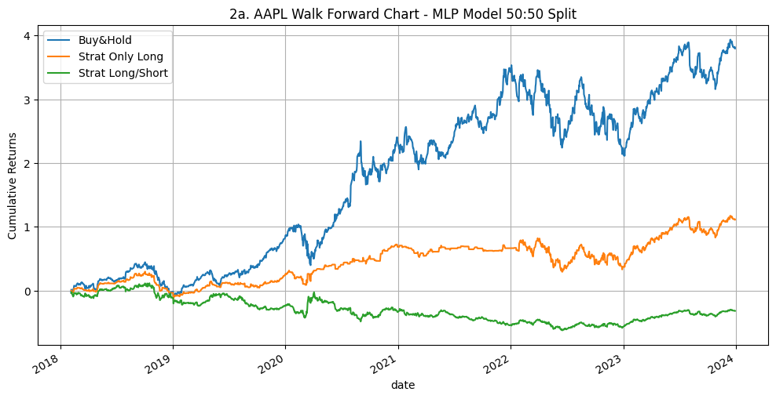

```python
compare_returns(df_res1)
plot_strategy(df_res1, '2a_mlp', "2a. AAPL Walk Forward Chart - MLP Model 50:50 Split")
```

Perform backtest for MLP Model

```python
backtest(df_res1).head()
```

|  | Value |
| --- | --- |
| Initial Capital | 10000.000000 |
| Final Portfolio Value | 34009.659801 |
| Percentage Gain | 240.096598 |
| Total Trades | 1486.000000 |
| Winning Trades | 772.000000 |

Next, we analyze the performance of the LSTM model under the setting of 50:50 train-test split.

```python
lstm_model = create_lstm_model(n_input)
df_res_lstm1 = walk_forward(df, lstm_model, 'LSTM', n_train, n_test)
df_res_lstm1.head()
```

```
0 ite  0.0  --start test: 2018-02-05  --end test 2020-01-30  -----  (500, 6) (500,) (500, 6) (500,) (500,) (500, 1)
(500,) (500,) (500,)
500 ite  1.0  --start test: 2020-01-31  --end test 2022-01-24  -----  (500, 6) (500,) (500, 6) (500,) (500,) (500, 1)
(1000,) (1000,) (1000,)
1000 ite  2.0  --start test: 2022-01-25  --end test 2023-12-29  -----  (500, 6) (500,) (486, 6) (486,) (486,) (486, 1)
Error occurred during LSTM model training: cannot reshape array of size 2916 into shape (500,1,6)
Reshape sucessful
```

|  | Date | Pred | Ret |
| --- | --- | --- | --- |
| 0 | 2018-02-05 | 0.463011 | -0.024984 |
| 1 | 2018-02-06 | 0.477012 | 0.041792 |
| 2 | 2018-02-07 | 0.627110 | -0.021407 |
| 3 | 2018-02-08 | 0.520291 | -0.027517 |
| 4 | 2018-02-09 | 0.480143 | 0.008121 |

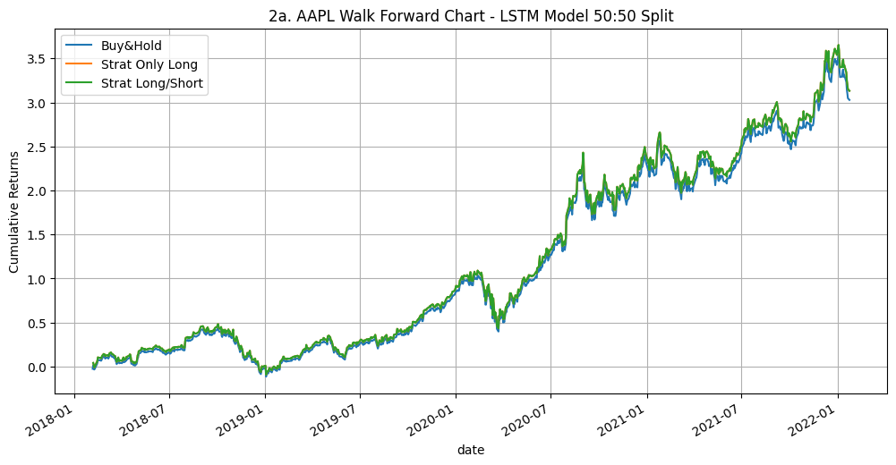

```python
compare_returns(df_res_lstm1)
plot_strategy(df_res_lstm1, '2a_lstm', "2a. AAPL Walk Forward Chart - LSTM Model 50:50 Split")
```

Backtest the LSTM Model

```python
backtest(df_res_lstm1).head()
```

|  | Value |
| --- | --- |
| Initial Capital | 10000.000000 |
| Final Portfolio Value | 49118.911839 |
| Percentage Gain | 391.189118 |
| Total Trades | 1000.000000 |
| Winning Trades | 1000.000000 |

Finally, we consider the CNN model with GAF representation.

```python
cnn_model = create_cnn_model()
df_res_cnn1 = walk_forward(df, cnn_model, 'CNN', n_train, n_test)
df_res_cnn1.head()
```

```
0 ite  0.0  --start test: 2018-02-05  --end test 2020-01-30  -----  (500, 6) (500,) (500, 6) (500,) (500,) (500, 1)
500
-> (500,) (398,) (500,)
500 ite  1.0  --start test: 2020-01-31  --end test 2022-01-24  -----  (500, 6) (500,) (500, 6) (500,) (500,) (500, 1)
1000
-> (1000,) (796,) (1000,)
1000 ite  2.0  --start test: 2022-01-25  --end test 2023-12-29  -----  (500, 6) (500,) (486, 6) (486,) (486,) (486, 1)
1486
-> (1486,) (1194,) (1486,)
```

|  | Date | Pred | Ret |
| --- | --- | --- | --- |
| 0 | 2018-02-05 | 0.531385 | -0.024984 |
| 1 | 2018-02-06 | 0.483311 | 0.041792 |
| 2 | 2018-02-07 | 0.555988 | -0.021407 |
| 3 | 2018-02-08 | 0.437057 | -0.027517 |
| 4 | 2018-02-09 | 0.554253 | 0.008121 |

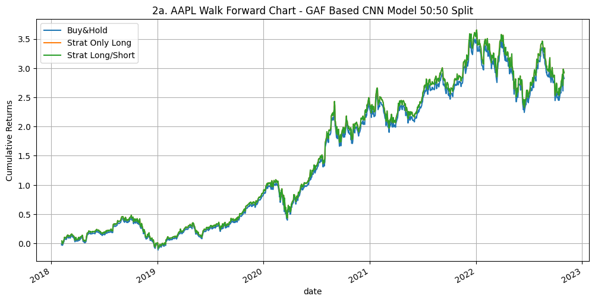

```python
compare_returns(df_res_cnn1)
plot_strategy(df_res_cnn1, '2a_cnn', "2a. AAPL Walk Forward Chart - GAF Based CNN Model 50:50 Split")
```

```python
backtest(df_res_cnn1).head()
```

|  | Value |
| --- | --- |
| Initial Capital | 10000.000000 |
| Final Portfolio Value | 49118.911839 |
| Percentage Gain | 391.189118 |
| Total Trades | 1194.000000 |
| Winning Trades | 1194.000000 |

## **Step 2b**

Secondly, we are working with a train-test split of 5:1, i.e., each model is trained on 500 observations and then testen on another 100 observations.

```python
n_input = 6
df = data
n_train = 500
n_test = 100
```

```python
mlp_model = create_mlp_model(n_input)
df_res2 = walk_forward(df, mlp_model, 'MLP',  n_train, n_test)
df_res2.head()
```

```
0 ite  0.0  --start test: 2018-02-05  --end test 2018-06-27  -----  (500, 6) (500,) (100, 6) (100,) (100,) (100, 1)
100 ite  1.0  --start test: 2018-06-28  --end test 2018-11-16  -----  (500, 6) (500,) (100, 6) (100,) (100,) (100, 1)
200 ite  2.0  --start test: 2018-11-19  --end test 2019-04-15  -----  (500, 6) (500,) (100, 6) (100,) (100,) (100, 1)
300 ite  3.0  --start test: 2019-04-16  --end test 2019-09-06  -----  (500, 6) (500,) (100, 6) (100,) (100,) (100, 1)
400 ite  4.0  --start test: 2019-09-09  --end test 2020-01-30  -----  (500, 6) (500,) (100, 6) (100,) (100,) (100, 1)
500 ite  5.0  --start test: 2020-01-31  --end test 2020-06-23  -----  (500, 6) (500,) (100, 6) (100,) (100,) (100, 1)
600 ite  6.0  --start test: 2020-06-24  --end test 2020-11-12  -----  (500, 6) (500,) (100, 6) (100,) (100,) (100, 1)
700 ite  7.0  --start test: 2020-11-13  --end test 2021-04-09  -----  (500, 6) (500,) (100, 6) (100,) (100,) (100, 1)
800 ite  8.0  --start test: 2021-04-12  --end test 2021-08-31  -----  (500, 6) (500,) (100, 6) (100,) (100,) (100, 1)
900 ite  9.0  --start test: 2021-09-01  --end test 2022-01-24  -----  (500, 6) (500,) (100, 6) (100,) (100,) (100, 1)
1000 ite  10.0  --start test: 2022-01-25  --end test 2022-06-16  -----  (500, 6) (500,) (100, 6) (100,) (100,) (100, 1)
1100 ite  11.0  --start test: 2022-06-17  --end test 2022-11-08  -----  (500, 6) (500,) (100, 6) (100,) (100,) (100, 1)
1200 ite  12.0  --start test: 2022-11-09  --end test 2023-04-04  -----  (500, 6) (500,) (100, 6) (100,) (100,) (100, 1)
1300 ite  13.0  --start test: 2023-04-05  --end test 2023-08-28  -----  (500, 6) (500,) (100, 6) (100,) (100,) (100, 1)
1400 ite  14.0  --start test: 2023-08-29  --end test 2023-12-29  -----  (500, 6) (500,) (86, 6) (86,) (86,) (86, 1)
```

|  | Date | Pred | Ret |
| --- | --- | --- | --- |
| 0 | 2018-02-05 | -0.043688 | -0.024984 |
| 1 | 2018-02-06 | -0.023379 | 0.041792 |
| 2 | 2018-02-07 | 0.038467 | -0.021407 |
| 3 | 2018-02-08 | -0.014885 | -0.027517 |
| 4 | 2018-02-09 | -0.022456 | 0.008121 |

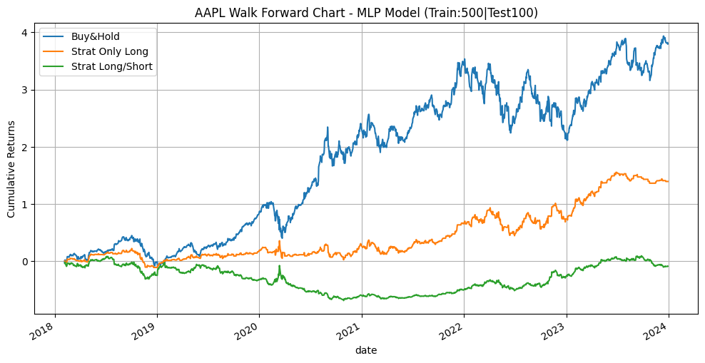

```python
compare_returns(df_res2)
plot_strategy(df_res2, '2b_mlp', f"AAPL Walk Forward Chart - MLP Model (Train:{n_train}|Test{n_test})")
```

```python
backtest(df_res2).head()
```

|  | Value |
| --- | --- |
| Initial Capital | 10000.000000 |
| Final Portfolio Value | 28779.660927 |
| Percentage Gain | 187.796609 |
| Total Trades | 1486.000000 |
| Winning Trades | 728.000000 |

```python
lstm_model = create_lstm_model(n_input);
df_res_lstm2 = walk_forward(df, lstm_model, 'LSTM', n_train, n_test)
df_res_lstm2.head()
```

```
0 ite  0.0  --start test: 2018-02-05  --end test 2018-06-27  -----  (500, 6) (500,) (100, 6) (100,) (100,) (100, 1)
(100,) (100,) (100,)
100 ite  1.0  --start test: 2018-06-28  --end test 2018-11-16  -----  (500, 6) (500,) (100, 6) (100,) (100,) (100, 1)
(200,) (200,) (200,)
200 ite  2.0  --start test: 2018-11-19  --end test 2019-04-15  -----  (500, 6) (500,) (100, 6) (100,) (100,) (100, 1)
(300,) (300,) (300,)
300 ite  3.0  --start test: 2019-04-16  --end test 2019-09-06  -----  (500, 6) (500,) (100, 6) (100,) (100,) (100, 1)
(400,) (400,) (400,)
400 ite  4.0  --start test: 2019-09-09  --end test 2020-01-30  -----  (500, 6) (500,) (100, 6) (100,) (100,) (100, 1)
(500,) (500,) (500,)
500 ite  5.0  --start test: 2020-01-31  --end test 2020-06-23  -----  (500, 6) (500,) (100, 6) (100,) (100,) (100, 1)
(600,) (600,) (600,)
600 ite  6.0  --start test: 2020-06-24  --end test 2020-11-12  -----  (500, 6) (500,) (100, 6) (100,) (100,) (100, 1)
(700,) (700,) (700,)
700 ite  7.0  --start test: 2020-11-13  --end test 2021-04-09  -----  (500, 6) (500,) (100, 6) (100,) (100,) (100, 1)
(800,) (800,) (800,)
800 ite  8.0  --start test: 2021-04-12  --end test 2021-08-31  -----  (500, 6) (500,) (100, 6) (100,) (100,) (100, 1)
(900,) (900,) (900,)
900 ite  9.0  --start test: 2021-09-01  --end test 2022-01-24  -----  (500, 6) (500,) (100, 6) (100,) (100,) (100, 1)
(1000,) (1000,) (1000,)
1000 ite  10.0  --start test: 2022-01-25  --end test 2022-06-16  -----  (500, 6) (500,) (100, 6) (100,) (100,) (100, 1)
(1100,) (1100,) (1100,)
1100 ite  11.0  --start test: 2022-06-17  --end test 2022-11-08  -----  (500, 6) (500,) (100, 6) (100,) (100,) (100, 1)
(1200,) (1200,) (1200,)
1200 ite  12.0  --start test: 2022-11-09  --end test 2023-04-04  -----  (500, 6) (500,) (100, 6) (100,) (100,) (100, 1)
(1300,) (1300,) (1300,)
1300 ite  13.0  --start test: 2023-04-05  --end test 2023-08-28  -----  (500, 6) (500,) (100, 6) (100,) (100,) (100, 1)
(1400,) (1400,) (1400,)
1400 ite  14.0  --start test: 2023-08-29  --end test 2023-12-29  -----  (500, 6) (500,) (86, 6) (86,) (86,) (86, 1)
Error occurred during LSTM model training: cannot reshape array of size 516 into shape (100,1,6)
Reshape sucessful
```

|  | Date | Pred | Ret |
| --- | --- | --- | --- |
| 0 | 2018-02-05 | 0.320449 | -0.024984 |
| 1 | 2018-02-06 | 0.307041 | 0.041792 |
| 2 | 2018-02-07 | 0.511079 | -0.021407 |
| 3 | 2018-02-08 | 0.375710 | -0.027517 |
| 4 | 2018-02-09 | 0.317908 | 0.008121 |

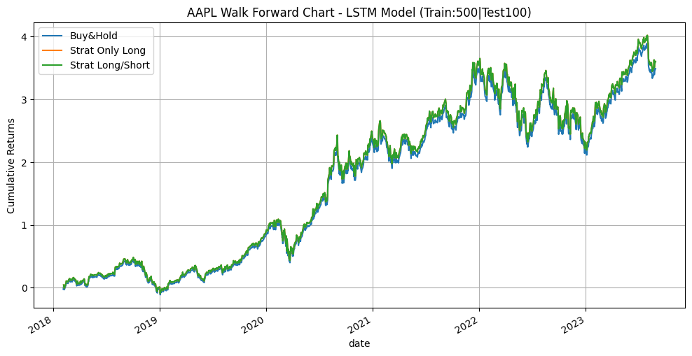

```python
compare_returns(df_res_lstm2)
plot_strategy(df_res_lstm2, '2b_lstm', f"AAPL Walk Forward Chart - LSTM Model (Train:{n_train}|Test{n_test})")
```

```python
backtest(df_res_lstm2).head()
```

|  | Value |
| --- | --- |
| Initial Capital | 10000.000000 |
| Final Portfolio Value | 49118.911839 |
| Percentage Gain | 391.189118 |
| Total Trades | 1400.000000 |
| Winning Trades | 1400.000000 |

```python
cnn_model = create_cnn_model()
df_res_cnn2 = walk_forward(df, cnn_model, 'CNN', n_train, n_test)
df_res_cnn2.head()
```

```
0 ite  0.0  --start test: 2018-02-05  --end test 2018-06-27  -----  (500, 6) (500,) (100, 6) (100,) (100,) (100, 1)
100
-> (100,) (398,) (100,)
100 ite  1.0  --start test: 2018-06-28  --end test 2018-11-16  -----  (500, 6) (500,) (100, 6) (100,) (100,) (100, 1)
200
-> (200,) (796,) (200,)
200 ite  2.0  --start test: 2018-11-19  --end test 2019-04-15  -----  (500, 6) (500,) (100, 6) (100,) (100,) (100, 1)
300
-> (300,) (1194,) (300,)
300 ite  3.0  --start test: 2019-04-16  --end test 2019-09-06  -----  (500, 6) (500,) (100, 6) (100,) (100,) (100, 1)
400
-> (400,) (1592,) (400,)
400 ite  4.0  --start test: 2019-09-09  --end test 2020-01-30  -----  (500, 6) (500,) (100, 6) (100,) (100,) (100, 1)
500
-> (500,) (1990,) (500,)
500 ite  5.0  --start test: 2020-01-31  --end test 2020-06-23  -----  (500, 6) (500,) (100, 6) (100,) (100,) (100, 1)
600
-> (600,) (2388,) (600,)
600 ite  6.0  --start test: 2020-06-24  --end test 2020-11-12  -----  (500, 6) (500,) (100, 6) (100,) (100,) (100, 1)
700
-> (700,) (2786,) (700,)
700 ite  7.0  --start test: 2020-11-13  --end test 2021-04-09  -----  (500, 6) (500,) (100, 6) (100,) (100,) (100, 1)
800
-> (800,) (3184,) (800,)
800 ite  8.0  --start test: 2021-04-12  --end test 2021-08-31  -----  (500, 6) (500,) (100, 6) (100,) (100,) (100, 1)
900
-> (900,) (3582,) (900,)
900 ite  9.0  --start test: 2021-09-01  --end test 2022-01-24  -----  (500, 6) (500,) (100, 6) (100,) (100,) (100, 1)
1000
-> (1000,) (3980,) (1000,)
1000 ite  10.0  --start test: 2022-01-25  --end test 2022-06-16  -----  (500, 6) (500,) (100, 6) (100,) (100,) (100, 1)
1100
-> (1100,) (4378,) (1100,)
1100 ite  11.0  --start test: 2022-06-17  --end test 2022-11-08  -----  (500, 6) (500,) (100, 6) (100,) (100,) (100, 1)
1200
-> (1200,) (4776,) (1200,)
1200 ite  12.0  --start test: 2022-11-09  --end test 2023-04-04  -----  (500, 6) (500,) (100, 6) (100,) (100,) (100, 1)
1300
-> (1300,) (5174,) (1300,)
1300 ite  13.0  --start test: 2023-04-05  --end test 2023-08-28  -----  (500, 6) (500,) (100, 6) (100,) (100,) (100, 1)
1400
-> (1400,) (5572,) (1400,)
1400 ite  14.0  --start test: 2023-08-29  --end test 2023-12-29  -----  (500, 6) (500,) (86, 6) (86,) (86,) (86, 1)
1486
-> (1486,) (5970,) (1486,)
```

|  | Date | Pred | Ret |
| --- | --- | --- | --- |
| 0 | 2018-02-05 | 0.504124 | -0.024984 |
| 1 | 2018-02-06 | 0.502019 | 0.041792 |
| 2 | 2018-02-07 | 0.581306 | -0.021407 |
| 3 | 2018-02-08 | 0.436086 | -0.027517 |
| 4 | 2018-02-09 | 0.537314 | 0.008121 |

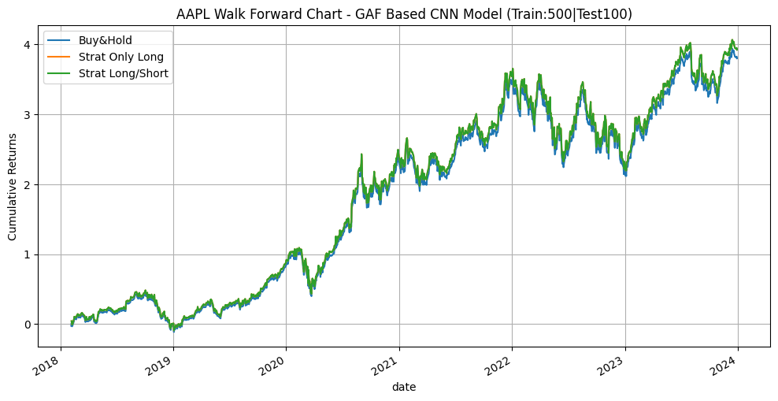

```python
compare_returns(df_res_cnn2)
plot_strategy(df_res_cnn2, '2b_cnn', f"AAPL Walk Forward Chart - GAF Based CNN Model (Train:{n_train}|Test{n_test})")
```

```python
backtest(df_res_cnn2).head()
```

|  | Value |
| --- | --- |
| Initial Capital | 10000.000000 |
| Final Portfolio Value | 49118.911839 |
| Percentage Gain | 391.189118 |
| Total Trades | 1486.000000 |
| Winning Trades | 1486.000000 |

## **Step 2c**

Now we compare the performance of the models from Step 2 to the models from Step 1.

Relative to the traditional backtesting, the walk-forward model (WFM) testing results demonstrate significantly better returns due to the real-time trading update and reduced risk of overfitting. The walk forward by its nature adapts to the evolving market conditions and phases, and thus performs better.

## **Step 2d**

# **Step 3**

## **Step 3a**

Now we alleviate the data leakage by ensuring that X is not affected by data shift anymore. This should prevent overfitting, as identified in Steps 1 and 2.

```python
# Initalize features and target
X = data[data.columns[-6:]]
y = data['Returns']
```

## **Step 3b**

Similarly as in Step 2a, we perform model comparison on a 50:50 train-test split.

```python
n_input = 6
df = data
n_train = 500
n_test = 500
```

```python
mlp_model = create_mlp_model(n_input)
df_res3 = walk_forward(df, mlp_model, 'MLP', n_train, n_test)
df_res3.head()
```

```
0 ite  0.0  --start test: 2018-02-05  --end test 2020-01-30  -----  (500, 6) (500,) (500, 6) (500,) (500,) (500, 1)
500 ite  1.0  --start test: 2020-01-31  --end test 2022-01-24  -----  (500, 6) (500,) (500, 6) (500,) (500,) (500, 1)
1000 ite  2.0  --start test: 2022-01-25  --end test 2023-12-29  -----  (500, 6) (500,) (486, 6) (486,) (486,) (486, 1)
```

|  | Date | Pred | Ret |
| --- | --- | --- | --- |
| 0 | 2018-02-05 | -0.011016 | -0.024984 |
| 1 | 2018-02-06 | -0.005083 | 0.041792 |
| 2 | 2018-02-07 | 0.004704 | -0.021407 |
| 3 | 2018-02-08 | -0.007618 | -0.027517 |
| 4 | 2018-02-09 | -0.007267 | 0.008121 |

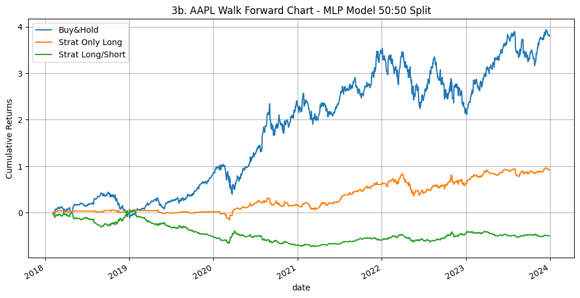

```python
compare_returns(df_res3)
plot_strategy(df_res3, '3b_mlp', "3b. AAPL Walk Forward Chart - MLP Model 50:50 Split")
```

```python
backtest(df_res3).head()
```

|  | Value |
| --- | --- |
| Initial Capital | 10000.000000 |
| Final Portfolio Value | 34396.109097 |
| Percentage Gain | 243.961091 |
| Total Trades | 1486.000000 |
| Winning Trades | 635.000000 |

### LSTM

```python
lstm_model = create_lstm_model(n_input)
df_res_lstm3 = walk_forward(df, lstm_model, 'LSTM', n_train, n_test)
df_res_lstm3.head()
```

```
0 ite  0.0  --start test: 2018-02-05  --end test 2020-01-30  -----  (500, 6) (500,) (500, 6) (500,) (500,) (500, 1)
(500,) (500,) (500,)
500 ite  1.0  --start test: 2020-01-31  --end test 2022-01-24  -----  (500, 6) (500,) (500, 6) (500,) (500,) (500, 1)
(1000,) (1000,) (1000,)
1000 ite  2.0  --start test: 2022-01-25  --end test 2023-12-29  -----  (500, 6) (500,) (486, 6) (486,) (486,) (486, 1)
Error occurred during LSTM model training: cannot reshape array of size 2916 into shape (500,1,6)
Reshape sucessful
```

|  | Date | Pred | Ret |
| --- | --- | --- | --- |
| 0 | 2018-02-05 | 0.515973 | -0.024984 |
| 1 | 2018-02-06 | 0.490189 | 0.041792 |
| 2 | 2018-02-07 | 0.554563 | -0.021407 |
| 3 | 2018-02-08 | 0.542477 | -0.027517 |
| 4 | 2018-02-09 | 0.493872 | 0.008121 |

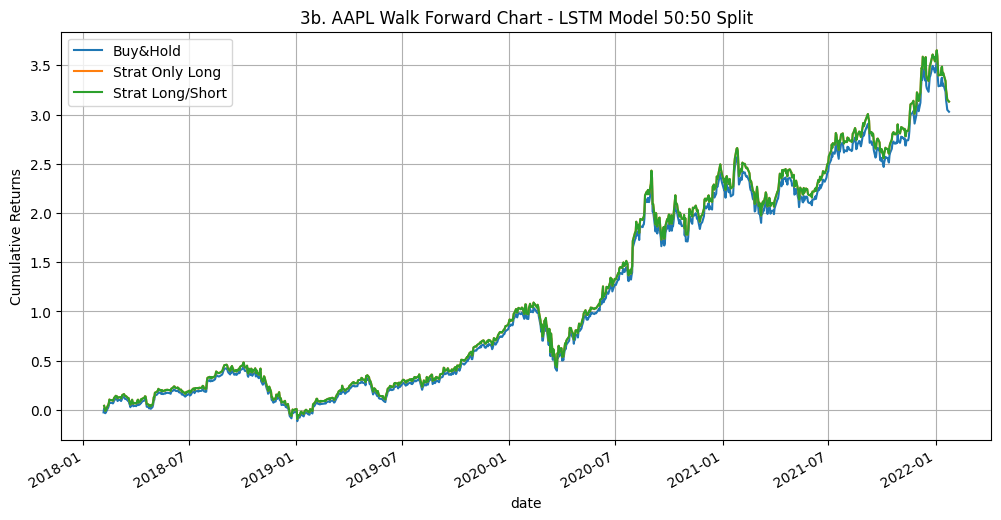

```python
compare_returns(df_res_lstm3)
plot_strategy(df_res_lstm3, '3b_lstm', "3b. AAPL Walk Forward Chart - LSTM Model 50:50 Split")
```

```python
backtest(df_res_lstm3).head()
```

|  | Value |
| --- | --- |
| Initial Capital | 10000.000000 |
| Final Portfolio Value | 49118.911839 |
| Percentage Gain | 391.189118 |
| Total Trades | 1000.000000 |
| Winning Trades | 1000.000000 |

### CNN with GAF Representation

```python
cnn_model = create_cnn_model()
df_res_cnn3 = walk_forward(df, cnn_model, 'CNN', n_train, n_test)
df_res_cnn3.head()
```

```
0 ite  0.0  --start test: 2018-02-05  --end test 2020-01-30  -----  (500, 6) (500,) (500, 6) (500,) (500,) (500, 1)
500
-> (500,) (398,) (500,)
500 ite  1.0  --start test: 2020-01-31  --end test 2022-01-24  -----  (500, 6) (500,) (500, 6) (500,) (500,) (500, 1)
1000
-> (1000,) (796,) (1000,)
1000 ite  2.0  --start test: 2022-01-25  --end test 2023-12-29  -----  (500, 6) (500,) (486, 6) (486,) (486,) (486, 1)
1486
-> (1486,) (1194,) (1486,)
```

|  | Date | Pred | Ret |
| --- | --- | --- | --- |
| 0 | 2018-02-05 | 0.491523 | -0.024984 |
| 1 | 2018-02-06 | 0.512545 | 0.041792 |
| 2 | 2018-02-07 | 0.535311 | -0.021407 |
| 3 | 2018-02-08 | 0.440879 | -0.027517 |
| 4 | 2018-02-09 | 0.553223 | 0.008121 |

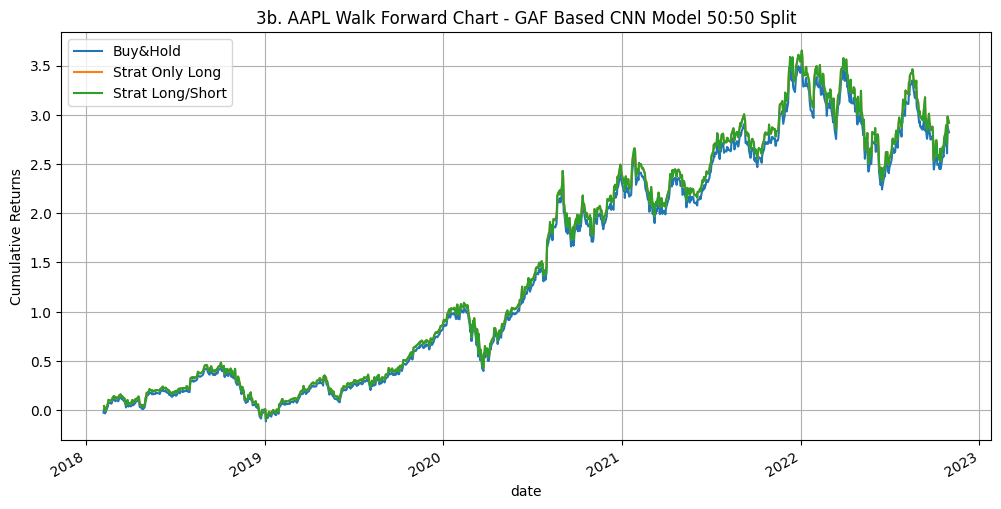

```python
compare_returns(df_res_cnn3)
plot_strategy(df_res_cnn3, '3b_cnn', "3b. AAPL Walk Forward Chart - GAF Based CNN Model 50:50 Split")
```

```python
backtest(df_res_cnn3).head()
```

|  | Value |
| --- | --- |
| Initial Capital | 10000.000000 |
| Final Portfolio Value | 49118.911839 |
| Percentage Gain | 391.189118 |
| Total Trades | 1194.000000 |
| Winning Trades | 1194.000000 |

## **Step 3c**

Analogically to in Step 2b, we perform model comparison on a 500:100 train-test split.

```python
n_input = 6
df = data
n_train = 500
n_test = 100
```

### MLP

```python
mlp_model = create_mlp_model(n_input)
df_res4 = walk_forward(df, mlp_model, 'MLP',  n_train, n_test)
df_res4.head()
```

```
0 ite  0.0  --start test: 2018-02-05  --end test 2018-06-27  -----  (500, 6) (500,) (100, 6) (100,) (100,) (100, 1)
100 ite  1.0  --start test: 2018-06-28  --end test 2018-11-16  -----  (500, 6) (500,) (100, 6) (100,) (100,) (100, 1)
200 ite  2.0  --start test: 2018-11-19  --end test 2019-04-15  -----  (500, 6) (500,) (100, 6) (100,) (100,) (100, 1)
300 ite  3.0  --start test: 2019-04-16  --end test 2019-09-06  -----  (500, 6) (500,) (100, 6) (100,) (100,) (100, 1)
400 ite  4.0  --start test: 2019-09-09  --end test 2020-01-30  -----  (500, 6) (500,) (100, 6) (100,) (100,) (100, 1)
500 ite  5.0  --start test: 2020-01-31  --end test 2020-06-23  -----  (500, 6) (500,) (100, 6) (100,) (100,) (100, 1)
600 ite  6.0  --start test: 2020-06-24  --end test 2020-11-12  -----  (500, 6) (500,) (100, 6) (100,) (100,) (100, 1)
700 ite  7.0  --start test: 2020-11-13  --end test 2021-04-09  -----  (500, 6) (500,) (100, 6) (100,) (100,) (100, 1)
800 ite  8.0  --start test: 2021-04-12  --end test 2021-08-31  -----  (500, 6) (500,) (100, 6) (100,) (100,) (100, 1)
900 ite  9.0  --start test: 2021-09-01  --end test 2022-01-24  -----  (500, 6) (500,) (100, 6) (100,) (100,) (100, 1)
1000 ite  10.0  --start test: 2022-01-25  --end test 2022-06-16  -----  (500, 6) (500,) (100, 6) (100,) (100,) (100, 1)
1100 ite  11.0  --start test: 2022-06-17  --end test 2022-11-08  -----  (500, 6) (500,) (100, 6) (100,) (100,) (100, 1)
1200 ite  12.0  --start test: 2022-11-09  --end test 2023-04-04  -----  (500, 6) (500,) (100, 6) (100,) (100,) (100, 1)
1300 ite  13.0  --start test: 2023-04-05  --end test 2023-08-28  -----  (500, 6) (500,) (100, 6) (100,) (100,) (100, 1)
1400 ite  14.0  --start test: 2023-08-29  --end test 2023-12-29  -----  (500, 6) (500,) (86, 6) (86,) (86,) (86, 1)
```

|  | Date | Pred | Ret |
| --- | --- | --- | --- |
| 0 | 2018-02-05 | -0.016565 | -0.024984 |
| 1 | 2018-02-06 | -0.005966 | 0.041792 |
| 2 | 2018-02-07 | 0.006703 | -0.021407 |
| 3 | 2018-02-08 | -0.002534 | -0.027517 |
| 4 | 2018-02-09 | -0.012318 | 0.008121 |

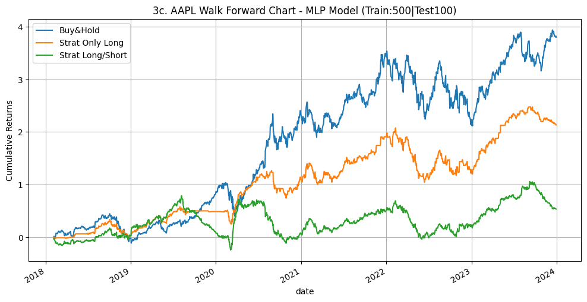

```python
compare_returns(df_res4)
plot_strategy(df_res4, '3c_mlp', f"3c. AAPL Walk Forward Chart - MLP Model (Train:{n_train}|Test{n_test})")
```

```python
backtest(df_res4).head()
```

|  | Value |
| --- | --- |
| Initial Capital | 10000.000000 |
| Final Portfolio Value | 33295.402351 |
| Percentage Gain | 232.954024 |
| Total Trades | 1486.000000 |
| Winning Trades | 710.000000 |

### LSTM

```python
lstm_model = create_lstm_model(n_input);
df_res_lstm4 = walk_forward(df, lstm_model, 'LSTM', n_train, n_test)
df_res_lstm4.head()
```

```
0 ite  0.0  --start test: 2018-02-05  --end test 2018-06-27  -----  (500, 6) (500,) (100, 6) (100,) (100,) (100, 1)
(100,) (100,) (100,)
100 ite  1.0  --start test: 2018-06-28  --end test 2018-11-16  -----  (500, 6) (500,) (100, 6) (100,) (100,) (100, 1)
(200,) (200,) (200,)
200 ite  2.0  --start test: 2018-11-19  --end test 2019-04-15  -----  (500, 6) (500,) (100, 6) (100,) (100,) (100, 1)
(300,) (300,) (300,)
300 ite  3.0  --start test: 2019-04-16  --end test 2019-09-06  -----  (500, 6) (500,) (100, 6) (100,) (100,) (100, 1)
(400,) (400,) (400,)
400 ite  4.0  --start test: 2019-09-09  --end test 2020-01-30  -----  (500, 6) (500,) (100, 6) (100,) (100,) (100, 1)
(500,) (500,) (500,)
500 ite  5.0  --start test: 2020-01-31  --end test 2020-06-23  -----  (500, 6) (500,) (100, 6) (100,) (100,) (100, 1)
(600,) (600,) (600,)
600 ite  6.0  --start test: 2020-06-24  --end test 2020-11-12  -----  (500, 6) (500,) (100, 6) (100,) (100,) (100, 1)
(700,) (700,) (700,)
700 ite  7.0  --start test: 2020-11-13  --end test 2021-04-09  -----  (500, 6) (500,) (100, 6) (100,) (100,) (100, 1)
(800,) (800,) (800,)
800 ite  8.0  --start test: 2021-04-12  --end test 2021-08-31  -----  (500, 6) (500,) (100, 6) (100,) (100,) (100, 1)
(900,) (900,) (900,)
900 ite  9.0  --start test: 2021-09-01  --end test 2022-01-24  -----  (500, 6) (500,) (100, 6) (100,) (100,) (100, 1)
(1000,) (1000,) (1000,)
1000 ite  10.0  --start test: 2022-01-25  --end test 2022-06-16  -----  (500, 6) (500,) (100, 6) (100,) (100,) (100, 1)
(1100,) (1100,) (1100,)
1100 ite  11.0  --start test: 2022-06-17  --end test 2022-11-08  -----  (500, 6) (500,) (100, 6) (100,) (100,) (100, 1)
(1200,) (1200,) (1200,)
1200 ite  12.0  --start test: 2022-11-09  --end test 2023-04-04  -----  (500, 6) (500,) (100, 6) (100,) (100,) (100, 1)
(1300,) (1300,) (1300,)
1300 ite  13.0  --start test: 2023-04-05  --end test 2023-08-28  -----  (500, 6) (500,) (100, 6) (100,) (100,) (100, 1)
(1400,) (1400,) (1400,)
1400 ite  14.0  --start test: 2023-08-29  --end test 2023-12-29  -----  (500, 6) (500,) (86, 6) (86,) (86,) (86, 1)
Error occurred during LSTM model training: cannot reshape array of size 516 into shape (100,1,6)
Reshape sucessful
```

|  | Date | Pred | Ret |
| --- | --- | --- | --- |
| 0 | 2018-02-05 | 0.379595 | -0.024984 |
| 1 | 2018-02-06 | 0.362510 | 0.041792 |
| 2 | 2018-02-07 | 0.413401 | -0.021407 |
| 3 | 2018-02-08 | 0.364725 | -0.027517 |
| 4 | 2018-02-09 | 0.368187 | 0.008121 |

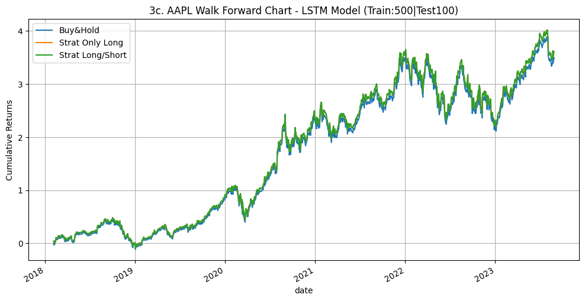

```python
compare_returns(df_res_lstm4)
plot_strategy(df_res_lstm4, '3c_lstm', f"3c. AAPL Walk Forward Chart - LSTM Model (Train:{n_train}|Test{n_test})")
```

```python
backtest(df_res_lstm4).head()
```

|  | Value |
| --- | --- |
| Initial Capital | 10000.000000 |
| Final Portfolio Value | 49118.911839 |
| Percentage Gain | 391.189118 |
| Total Trades | 1400.000000 |
| Winning Trades | 1400.000000 |

### CNN with GAF Representation

```python
cnn_model = create_cnn_model()
df_res_cnn4 = walk_forward(df, cnn_model, 'CNN', n_train, n_test)
df_res_cnn4.head()
```

```
0 ite  0.0  --start test: 2018-02-05  --end test 2018-06-27  -----  (500, 6) (500,) (100, 6) (100,) (100,) (100, 1)
100
-> (100,) (398,) (100,)
100 ite  1.0  --start test: 2018-06-28  --end test 2018-11-16  -----  (500, 6) (500,) (100, 6) (100,) (100,) (100, 1)
200
-> (200,) (796,) (200,)
200 ite  2.0  --start test: 2018-11-19  --end test 2019-04-15  -----  (500, 6) (500,) (100, 6) (100,) (100,) (100, 1)
300
-> (300,) (1194,) (300,)
300 ite  3.0  --start test: 2019-04-16  --end test 2019-09-06  -----  (500, 6) (500,) (100, 6) (100,) (100,) (100, 1)
400
-> (400,) (1592,) (400,)
400 ite  4.0  --start test: 2019-09-09  --end test 2020-01-30  -----  (500, 6) (500,) (100, 6) (100,) (100,) (100, 1)
500
-> (500,) (1990,) (500,)
500 ite  5.0  --start test: 2020-01-31  --end test 2020-06-23  -----  (500, 6) (500,) (100, 6) (100,) (100,) (100, 1)
600
-> (600,) (2388,) (600,)
600 ite  6.0  --start test: 2020-06-24  --end test 2020-11-12  -----  (500, 6) (500,) (100, 6) (100,) (100,) (100, 1)
700
-> (700,) (2786,) (700,)
700 ite  7.0  --start test: 2020-11-13  --end test 2021-04-09  -----  (500, 6) (500,) (100, 6) (100,) (100,) (100, 1)
800
-> (800,) (3184,) (800,)
800 ite  8.0  --start test: 2021-04-12  --end test 2021-08-31  -----  (500, 6) (500,) (100, 6) (100,) (100,) (100, 1)
900
-> (900,) (3582,) (900,)
900 ite  9.0  --start test: 2021-09-01  --end test 2022-01-24  -----  (500, 6) (500,) (100, 6) (100,) (100,) (100, 1)
1000
-> (1000,) (3980,) (1000,)
1000 ite  10.0  --start test: 2022-01-25  --end test 2022-06-16  -----  (500, 6) (500,) (100, 6) (100,) (100,) (100, 1)
1100
-> (1100,) (4378,) (1100,)
1100 ite  11.0  --start test: 2022-06-17  --end test 2022-11-08  -----  (500, 6) (500,) (100, 6) (100,) (100,) (100, 1)
1200
-> (1200,) (4776,) (1200,)
1200 ite  12.0  --start test: 2022-11-09  --end test 2023-04-04  -----  (500, 6) (500,) (100, 6) (100,) (100,) (100, 1)
1300
-> (1300,) (5174,) (1300,)
1300 ite  13.0  --start test: 2023-04-05  --end test 2023-08-28  -----  (500, 6) (500,) (100, 6) (100,) (100,) (100, 1)
1400
-> (1400,) (5572,) (1400,)
1400 ite  14.0  --start test: 2023-08-29  --end test 2023-12-29  -----  (500, 6) (500,) (86, 6) (86,) (86,) (86, 1)
1486
-> (1486,) (5970,) (1486,)
```

|  | Date | Pred | Ret |
| --- | --- | --- | --- |
| 0 | 2018-02-05 | 0.478843 | -0.024984 |
| 1 | 2018-02-06 | 0.514753 | 0.041792 |
| 2 | 2018-02-07 | 0.537916 | -0.021407 |
| 3 | 2018-02-08 | 0.445746 | -0.027517 |
| 4 | 2018-02-09 | 0.508057 | 0.008121 |

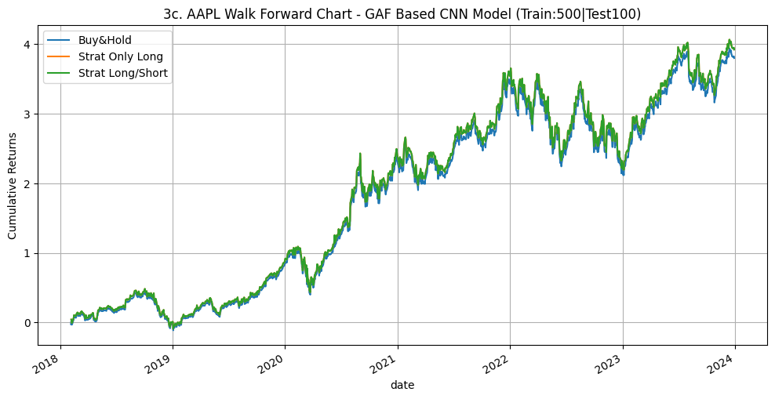

```python
compare_returns(df_res_cnn4)
plot_strategy(df_res_cnn4, '3c_cnn', f"3c. AAPL Walk Forward Chart - GAF Based CNN Model (Train:{n_train}|Test{n_test})")
```

```python
backtest(df_res_cnn4).head()
```

|  | Value |
| --- | --- |
| Initial Capital | 10000.000000 |
| Final Portfolio Value | 49118.911839 |
| Percentage Gain | 391.189118 |
| Total Trades | 1486.000000 |
| Winning Trades | 1486.000000 |

## **Step 3d**

# **References**

[1] Zhang A., Lipton, Li, and Smola A. Dive into Deep Learning, Cambridge University Press (2023).

[2] Rajan, Chitta. Understanding Deep Learning: Application in Rare Event Prediction (2020)

[3] Cook, Alexis Data Leakage https://www.kaggle.com/code/alexisbcook/data-leakage

[4] Gray, Chad. "Stock Prediction with ML: Walk-forward Modeling." The Alpha Scientist, 18 July 2018, https://alphascientist.com/walk_forward_model_building.html.